# PROJECT: Course Optimization for Data Science

## Optimization strategies for the proportional odds model

Author: Alexandre Gramfort

If you have questions or if something is not clear in the text below please contact us by email.

## Aim:

- Derive mathematically and implement the loss and gradients of the proportional odds model
- Implement your own solvers for L1 or L2 regularization with: (Accelerated) Proximal gradient descent and L-BFGS (only for L2)
- Implement your own scikit-learn estimator for the proportional odds model and test it on the `wine quality` dataset.

### Remarks:

- This project involves some numerical difficulty due to the presence of many `log` and `exp` functions.
- The correct and stable computation of the gradient is quite difficult. For this reason you have the possibility to use the `autograd` package to compute the gradient by automatic differentiation. `autograd` inspired the design of `pytorch`. It is a pure python package which makes it easy to install, and it is sufficient for our usecase.

## VERY IMPORTANT

This work must be done by pairs of students. Each student must send their work before the 20th of January at 23:59, using the moodle platform. This means that **each student in the pair sends the same file**

On the moodle, in the "Optimization for Data Science" course, you have a "devoir" section called "Project". This is where you submit your jupyter notebook file.

The name of the file must be constructed as in the next cell

### Gentle reminder: no evaluation if you don't respect this EXACTLY

#### How to construct the name of your file

```python
# Change here using YOUR first and last names
fn1 = "Yu"
ln1 = "Xiang"
fn2 = "Jean"
ln2 = "Babin"

filename = "_".join(map(lambda s: s.strip().lower(),
                        ["project", ln1, fn1, "and", ln2, fn2])) + ".ipynb"
print(filename)
```

```
project_xiang_yu_and_babin_jean.ipynb
```

Some imports

```python
%matplotlib inline
import numpy as np
from scipy import linalg
import time
import matplotlib.pyplot as plt
```

## Part 0: Proportional odds model

This model is an ordinal regression model. It is a supervised learning model, in the case where the target space $Y$ is discrete: $Y=\{1, \dots, k\}$; this is the case in multiclass classification for example. Its specificity is that we assume there is an order in the output space.

Intuitively, it means that if the true label is 2, predicting 5 is worse that predicting 3 (as 3 is closer to 2 than 5 is). For a usual classification loss, each bad prediction costs the same. In the case of the proportional odds model, **it costs more to predict values that are farther from the true target**.

The proportional odds model can be seen as an extension to the logistic regression model as we will see now.

Working with observations in $\mathbb{R}^p$, the proportional odds model has the following structure for $1 \leq j \leq k-1$:

$$ \log \left ( \frac{P(Y \leq j \mid x)}{P(Y > j \mid x)} \right ) = \alpha_j + \beta^T x , $$

where $\beta \in \mathbb{R}^p$ and $\alpha = \{ \alpha_j \}_{j=1}^{k-1}$ is an increasing sequence of constants ($\alpha_1 \leq \alpha_2 \leq \dots \leq \alpha_{k-1}$). We omit here the last term since $P(Y \leq k) = 1$. Since $P(Y > j | x) = 1 - P(Y \leq j | x)$, we can rewrite the previous equation as: $$ P(Y \leq j \mid x) = \frac{e^{\alpha_j + \beta^T x}}{e^{\alpha_j + \beta^T x} + 1} = \phi(\alpha_j + \beta^T x) $$

and

$$ P(Y = j \mid x) = \frac{e^{\alpha_j + \beta^T x}}{e^{\alpha_j + \beta^T x} + 1} - \frac{e^{\alpha_{j-1} + \beta^T x}}{e^{\alpha_{j-1} + \beta^T x} + 1} = \phi(\alpha_j + \beta^T x) - \phi(\alpha_{j-1} + \beta^T x) $$

for $2 \leq j \leq k-1$, where $\phi$ denotes the sigmoid function $\phi(t) = 1 / (1 + \exp(-t))$.

After one-hot encoding of the target variable ([`OneHotEncoder`](https://scikit-learn.org/stable/modules/generated/sklearn.preprocessing.OneHotEncoder.html), [`LabelBinarizer`](https://scikit-learn.org/stable/modules/generated/sklearn.preprocessing.LabelBinarizer.html)), denoting $\{ y_{ij} \}_{j=1}^{k}$ the indicator sequence for the class of the $i^{\text{th}}$ observation $x_i$ (i.e., exactly one of the $y_{ij}$ equals one and the rest are zero) the negative log likelihood becomes:

Introducing some $\ell_1$ or $\ell_2$ regularization on the parameter $\beta$ with regularization parameter $\lambda \ge 0$, the penalized likelihood estimation problem reads: $$ (\mathcal{P}_\alpha): \left\{ \begin{aligned} \min_{\alpha, \beta} \quad f(\alpha, \beta) + \lambda \mathcal{R}(\beta) \\ \alpha_1 \leq \dots \leq \alpha_{k-1} \end{aligned} \right. $$ where $\mathcal{R}(\beta) = \|\beta\|_1$ or $\tfrac{1}{2} \|\beta\|^2_2$

**QUESTION 1:**

- Justify that $(\mathcal{P}_\alpha)$ is a convex problem.

In the first exercise of this course(exe_convexity_smoothness.pdf), we have proved the following statements:

1. $\|\beta\|_1$ and $\tfrac{1}{2} \|\beta\|^2_2$ are both convex functions, and actually every norm is convex.

2. For every convex function $f : y ∈ \mathbb{R}^m → f (y)$, we have that $g : x ∈ \mathbb{R}^d → f (Ax − b)$ is a convex function, where $A ∈ \mathbb{R}^{m*d}$ and $b ∈ \mathbb{R}^m$.

3. $f_i : \mathbb{R}^d → \mathbb{R}$ be convex for $i = 1, ..., m$, then we have that $\sum_{i=1}^{m}f_i$ is convex

Further, we could prove that:

4. $h(x) = \log (1+ e^x)$ is convex, (here $e$ is the exponential constant)

5. $g(x) = \log (\frac{1}{e^{-x}-1})$ is convex

Statement 4 and Statement 5 could be easily proved by calculating the second order derivatives and check that they are positive for any real number x.

$$h^{''}(x) = \frac{e^x}{(1 + e^x)^2} > 0, \forall x$$ $$g^{''}(x) = \frac{e^x}{(e^x - 1)^2} > 0, \forall x $$

With above statements, we could prove that $(\mathcal{P}_\alpha)$ is a convex problem. First we show $f(\alpha, \beta)$ is a convex function.

Denote $z_j := \alpha_j + \beta^T x_i$, then $$f(\alpha, \beta) = \sum_{i=1}^{n} [-y_{i1} \log(\phi(z_1)) - \sum_{j=2}^{k-1} \Big( y_{ij} \log(\phi(z_j) - \phi(z_{j-1})\big) - y_{ik} \log(1 - \phi(z_{k-1})) ]$$

By statment 3, we only need to prove the addend of function $f(\alpha, \beta)$ is convex, i.e. we need to show the following three parts are convex functions to prove the convexity of function $f(\alpha, \beta)$.

- Addend 1: $-\log(\phi(z_1))$
- Addend 2: $-\log(\phi(z_j) - \phi(z_{j-1})$
- Addend 3$-\log(1 -\phi(z_{k-1}))$

We have $$ \phi(x) = \frac{e^x}{1+ e^x} = (1+ e^{-x})^{-1}$$ and Addend 1: $$-\log(\phi(z_1)) = \log (\phi(z_1)^{-1}) = \log (1+ e^{-z_1}): = h(-z_1)$$ and from statement 4, we have $h(z_j(x_i))$ is convex, combining statement 4 and statement 2, we know that $h(-z_1)$ is also convex ($z_1$ is linear transformation of $x$), i.e. we have shown that $-\log(\phi(z_1))$ is convex

Now we prove the convexity of Addend 2:

$$-\log(\phi(z_j) - \phi(z_{j-1}) = -\log((1+ e^{-z_j})^{-1} - (1+ e^{-z_{j-1}})^{-1}) = \log(1+ e^z_j) + \log(1+ e^z_{j-1}) - \log(e^z_{j-1} - e^z_j)$$

We know from statement 4 and 2 that $\log(1+ e^z_j)$ and $\log(1+ e^{j-1})$ are convex, moreover, we could prove that $-\log(e^z_{j-1} - e^z_j) $ is also convex. Denote: $\delta = z_j - z_{j-1} = \alpha_j - \alpha_{j-1}$

Then $$-\log(e^z_{j-1} - e^z_j) = -\log(e^{z_j - \delta}- e^z_j) = -\log (e^z_j(\frac{1}{e^\delta} -1)) = -z_j + \log((e^{-\delta} - 1)^{-1})$$ $z_j$ is convex, and the second order derivative of $\log((e^{-\delta} - 1)^{-1})$ is $\frac{e^{-\delta}}{(e^{-\delta}-1)^2}$, which is positive $\forall x$

Thus we have proved that Addend 2: $-\log(\phi(z_j) - \phi(z_{j-1})$ is also convex.

Similarly we could prove that Addend 3: is also convex.

Since function $f(\alpha, \beta)$ is just sum of Addend 1, a number of Addend 2 and Addend 3. Addend 1, 2 and 3 are all convex, therefore by statement 3, $f(\alpha, \beta)$ is convex.

Moreover, by statement 1, $\mathcal{R}(\beta)$ is convex.

And the domain of $\alpha, \beta$ is convex, since it is real number space. Then $(\mathcal{P}_\alpha)$ is a convex function defined on a convex domain, thus it is a convex problem.

## Simulation

Generate data under the above model and then estimate $\alpha$ and $\beta$ using maximum likelihood

```python
import numpy as np

n = 1000  # number of samples
p = 2  # number of features
k = 3  # number of classes
```

#### Generate parameters and compute probability distributions for each sample

```python
rng = np.random.RandomState(42)
X = 15 * rng.normal(size=(n, p))
alpha = np.sort(np.linspace(-10, 10, k - 1) + rng.randn(k - 1))
beta = rng.randn(p)
```

We want to compute the quantity $P(Y = j \mid x_i)$ for $j= 1, \dots , k$, and $i= 1, \dots, n$.

First, let us compute an array containing the values $P(Y < j \mid x_i)$ for $j= 1, \dots , k+1$ and $i=1, \dots, n$. (we denote this array `F`):

```python
def phi(t):
    return 1. / (1. + np.exp(-t))

F = phi(np.dot(X, beta)[:, np.newaxis] + alpha)
F = np.concatenate([np.zeros((n , 1)), F, np.ones((n , 1))], axis=1)
F
```

```
array([[0.00000000e+00, 1.19425874e-07, 9.89950079e-01, 1.00000000e+00],
       [0.00000000e+00, 9.22303606e-12, 7.54978894e-03, 1.00000000e+00],
       [0.00000000e+00, 1.10105626e-03, 9.99998900e-01, 1.00000000e+00],
       ...,
       [0.00000000e+00, 2.52740373e-09, 6.75810908e-01, 1.00000000e+00],
       [0.00000000e+00, 1.85838624e-03, 9.99999349e-01, 1.00000000e+00],
       [0.00000000e+00, 4.98712917e-03, 9.99999758e-01, 1.00000000e+00]])
```

```python
# compute P(Y = j | x)
proba = np.diff(F, axis=1)
assert proba.shape == (n, k)
proba
```

```
array([[1.19425874e-07, 9.89949960e-01, 1.00499208e-02],
       [9.22303606e-12, 7.54978894e-03, 9.92450211e-01],
       [1.10105626e-03, 9.98897844e-01, 1.09991567e-06],
       ...,
       [2.52740373e-09, 6.75810905e-01, 3.24189092e-01],
       [1.85838624e-03, 9.98140963e-01, 6.51184001e-07],
       [4.98712917e-03, 9.95012629e-01, 2.41894393e-07]])
```

The sum of all probas for each sample should be 1:

```python
np.testing.assert_allclose(np.sum(proba, axis=1), np.ones(n))
# numpy.testing.assert_allclose: Raises an AssertionError if two objects are not equal up to desired tolerance.
```

#### Simulate $Y$ according to $P(Y = j \mid x)$

```python
y = np.array([rng.choice(np.arange(k), size=1, p=pi)[0] for pi in proba])
y[:10]
```

```
array([1, 2, 1, 2, 1, 1, 1, 0, 1, 0])
```

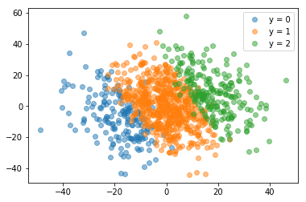

```python
for j in range(k):
    Xj = X[y == j]
    plt.plot(Xj[:, 0], Xj[:, 1], 'o', label='y = %d' % j, alpha=0.5)

plt.legend();
```

# Log-Likelihood function

We adopt the parametrization from $(\mathcal{P}_\alpha)$. The vector of parameters `params` has `k-1 + p` entries. The first `k-1` are the alphas $\alpha$ and the last `p` entries correspond to $\beta$. The function that predicts the probabilities of each sample reads:

```python
def predict_proba_alphas(params, X=X):
    """Compute the probability of each sample in X.

    Parameters:
    -----------
    params: array, shape (k - 1 + p,)
        Parameters of the model. The first k - 1 entries are the alpha_j,
        the remaining p ones are the entries of beta.

    X: array, shape (n, p)
        Design matrix.

    Returns
    -------
    proba : ndarray, shape (n, k)
        The proba of belonging to each class for each sample.
    """
    n_samples, n_features = X.shape
    n_thresh = params.size - n_features
    alpha = params[:n_thresh]
    beta = params[n_thresh:]
    F = phi(np.dot(X, beta)[:, np.newaxis] + alpha)
    F = np.concatenate(
        [np.zeros((n_samples , 1)), F, np.ones((n_samples , 1))], axis=1)
    proba = np.diff(F, axis=1)
    return proba
```

One-hot encoding of `y` can be done with scikit-learn `LabelBinarizer`. As it's a matrix, we call it `Y`:

```python
from sklearn import preprocessing

def binarize(y):
    le = preprocessing.LabelBinarizer()
    Y = le.fit_transform(y)
    if Y.shape[1] == 1:
        Y = np.concatenate([1 - Y, Y], axis=1)
    return Y

Y = binarize(y)
Y[:10]
```

```
array([[0, 1, 0],
       [0, 0, 1],
       [0, 1, 0],
       [0, 0, 1],
       [0, 1, 0],
       [0, 1, 0],
       [0, 1, 0],
       [1, 0, 0],
       [0, 1, 0],
       [1, 0, 0]])
```

The negative log-likelihood then reads:

```python
def negloglik_alphas(params, X=X, Y=Y):
    proba = predict_proba_alphas(params, X)
    assert Y.shape == proba.shape
    return -np.sum(np.log(np.sum(proba * Y, axis=1) + np.finfo('float').eps))

params = np.concatenate([alpha, beta])
negloglik_alphas(params)
```

```
173.86949983576653
```

**QUESTION 2:**

- Justify why applying coordinate descent or proximal gradient descent to $(\mathcal{P}_\alpha)$ is not easy (or even possible?).
- For coordinate descent method: When choosing one coordinate to minimize, e.g. minimizing $\mathcal{P}_\alpha$ with respect to $\alpha_i$, it may happen that $\alpha_i$ becomes bigger than $\alpha_{i+1}$, leading to a negative probablity, i.e. the constraints can not be fulfilled. Even if fortunately, the final result satisfies the constriants, we may not get the optimal solution becasue in some iterations, we get a fake optimal value of $\alpha_i$ (a value does not meet the constraints), leading to a doubtful(mostly likely not optimal) final result.
- For proximal gradient descent method, we will have difficulity to find a very simple explicit formula to calculate the term related to each $\alpha$ as they are correlated.

## Reparametrization

To fix the problem, we propose to reparametrize the problem with a new vector $\eta \in \mathbb{R}^{k-1}$ such that $\alpha_j = \sum_{l=1}^{j} \eta_l$ with $\eta_j \geq 0$ for $j \geq 2$.

We denote by $\mathcal{L}(\eta, \beta)$ the corresponding negative log-likelihood:

**QUESTION 3:**

- Show that $(\mathcal{P}_\alpha)$ can be rewritten as an unconstrained convex problem $(\mathcal{P}_\eta)$. $$ (\mathcal{P}_\eta): \left\{ \begin{aligned} \min_{\eta \in \mathbb{R}^{k-1}, \beta \in \mathbb{R}^{p}} \quad \mathcal{L}(\eta, \beta) + \lambda \mathcal{R}(\beta) + \sum_{j=2}^{k-1} g_j(\eta_j)\\ \end{aligned} \right. $$ You will detail what are the functions $g_j$.
- Justify that the problem can be solved with Proximal Gradient Descent, Proximal Coordinate Descent and the L-BFGS-B algorithm (implemented in scipy.optimize).

Define: $g(x) = L * (|x| - x)$, where $L$ is a number very large(approaching positive infinity) i.e. $$g(x) = \{ \begin{aligned} & 0, \ if \ x >= 0\\ & L \ ( where \ L \to + \infty), \ else \end{aligned}$$

Then $(\mathcal{P}_\eta)$ is equivalent to $(\mathcal{P}_\alpha)$ since the contraints in $(\mathcal{P}_\alpha)$ is translated into function $g_j$ for $j = 2, 3, ..., k-1$

Notice that the constraints in $(\mathcal{P}_\alpha)$ are: $\alpha_1 \leq \dots \leq \alpha_{k-1}$,

and now we have $\alpha_1 = \eta_1$, $\alpha_2 = \eta_1 + \eta_2$, ..., $\alpha_{k-1} = \sum_{l=1}^{k-1} \eta_l$, which are equivalently to that all $\eta_2, \eta_3, ..., \eta_{k-1}$ are positive.

$ g_j(\eta_j), j = 2, 3, ..., k-1$ equals to zero as long as $\eta_j > 0 $ and will become very large(approaching to the infinity)if not. Which means the objective value of $(\mathcal{P}_\alpha)$ and $(\mathcal{P}_\eta)$ will be the same when condition $\alpha_1 \leq \dots \leq \alpha_{k-1} $ in $(\mathcal{P}_\alpha)$ (the equivalently condition in $\mathcal{L}(\eta, \beta)$: $\eta_j >=0, j = 2, 3, ..., k-1$) is satisfied.

Therefore, $(\mathcal{P}_\eta)$ is equivalent to $(\mathcal{P}_\alpha)$.

Then we could use Proximal Gradient Descent, Proximal Coordinate Descent and and the L-BFGS-B algorithm as stated in the lecture slides, since they all only require to calculate the first order gradient.

The convexity of $\sum_{j=2}^{k-1} g_j(\eta_j)$ could be proved by showing that its addend is convex, as follows: \begin{aligned} g(\theta x + (1-\theta) y) &= L (|\theta x + (1-\theta) y| - \theta x + (1-\theta) y) \\ & <= L (|\theta x| + |(1-\theta) y| - \theta x + (1-\theta) y) \\ & = \theta L(|x| - x) + (1-\theta) L (|y| - y) \\ & = \theta g(x) + (1-\theta) g(y) \end{aligned} where $\theta \in [0,1]$

Without losing generosity, we let $L = 1e+8$, the actual effect is that when applying the proximaty operator:

- if the parameters is negative (but bigger than $-2L$), it will be converted to zero
- if the parameters is positive, it will remain unchanged

```python
L = 1e+8
```

**QUESTION 4:**

- Introducing the functions $f_2(\eta, \beta) = \tfrac{\lambda}{2}\|\beta\|_2^2 + \sum_{j=2}^{k-1} g_j(\eta_j)$ (corresponding to the case where $\mathcal{R}=\tfrac{1}{2}\|\beta\|_2^2$) and $f_1(\eta, \beta) = \lambda \|\beta\|_1 + \sum_{j=2}^{k-1} g_j(\eta_j)$ (corresponding to the case where $\mathcal{R}=\|\beta\|_1$), compute and implement the proximal operators of $f_1$ and $f_2$.

In the code below, `lambda` being a reserved keyword in Python, we denote $\lambda$ by `reg`.

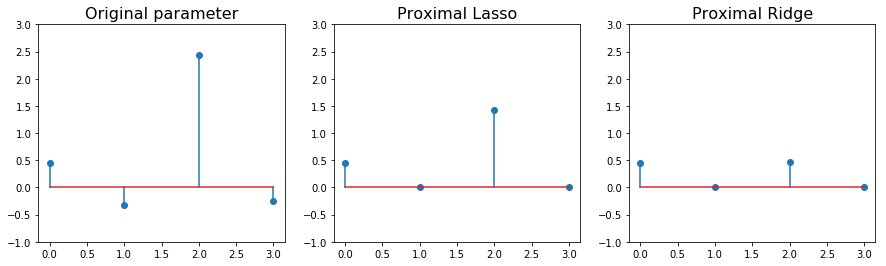

```python
def prox_f2(params, reg=1., n_classes=k):

    n_samples, n_features = X.shape
    n_thresh = params.size - n_features

    eta = params[:n_thresh]  # eta:  eta1 could be any number
    # eta2, eta3, ..., eta_{k-1} must be non-negative
    beta = params[n_thresh:]  # the first n_thresh beta
    beta_new = beta / (1 + reg)

    eta_new = eta.copy()

    eta_new[eta < -2 * L] = eta[eta< -2 * L] + 2 * L
    eta_new[np.logical_and(-2 * L <= eta, eta <= 0)] = 0
    eta_new[0] = eta[0] # For the first term of eta, there is no constraint

    params[:n_thresh] = eta_new
    params[n_thresh:] = beta_new

    return params


def prox_f1(params, reg=1., n_classes=k):
    # TODO

    n_samples, n_features = X.shape
    n_thresh = params.size - n_features

    eta = params[:n_thresh]
    beta = params[n_thresh:]  # the first n_thresh beta

    beta_new = np.sign(beta) * np.maximum(np.abs(beta) - reg, 0)
    eta_new = eta.copy()

    eta_new[eta < -2 * L] = eta[eta< -2 * L] + 2 * L
    eta_new[np.logical_and(-2 * L <= eta, eta <= 0)] = 0
    eta_new[0] = eta[0] # For the first term of eta, there is no constraint


    params[:n_thresh] = eta_new
    params[n_thresh:] = beta_new


    return params

rng = np.random.RandomState(5)
x = rng.randn(p + k - 1)
l_l1 = 1.
l_l2 = 2.
ylim = [-1, 3]

plt.figure(figsize=(15.0, 4.0))
plt.subplot(1, 3, 1)
plt.stem(x)
plt.title("Original parameter", fontsize=16)
plt.ylim(ylim)
plt.subplot(1, 3, 2)
plt.stem(prox_f1(x, l_l1))
plt.title("Proximal Lasso", fontsize=16)
plt.ylim(ylim)
plt.subplot(1, 3, 3)
plt.stem(prox_f2(x, l_l2))
plt.title("Proximal Ridge", fontsize=16)
plt.ylim(ylim)
plt.show()
```

## Part 1: Implementation of the solvers

### L-BFGS-B Solver

We will start by using the L-BFGS solver provided by `scipy`, without specifying the gradient function. In this case, the [`fmin_l_bfgs_b`](https://docs.scipy.org/doc/scipy/reference/generated/scipy.optimize.fmin_l_bfgs_b.html) function will approximate the gradient using a finite difference method.

**QUESTION 5:**

- Implement the new predict_proba function using the new parametrization with $\eta$

```python
def predict_proba(params, X=X):
    """Compute the probability of every sample in X.

    Parameters
    ----------
    params : ndarray, shape (k - 1 + p,)
        The parameters. The first k-1 values are the etas
        and the last p ones are beta.

    X: array, shape (n, p)
        Design matrix.

    Returns
    -------
    proba : ndarray, shape (n, k)
        The proba of belonging to each class for each sample.
    """
    n_samples, n_features = X.shape
    n_thresh = params.size - n_features
    eta = params[:n_thresh]
    beta = params[n_thresh:]
    alpha = eta.cumsum()


    F = phi(np.dot(X, beta)[:, np.newaxis] + alpha)
    F = np.concatenate(
        [np.zeros((n_samples , 1)), F, np.ones((n_samples , 1))], axis=1)
    proba = np.diff(F, axis=1)

    return proba


def negloglik(params, X=X, Y=Y):
    """Compute the negative log-likelihood.

    Parameters
    ----------
    params : ndarray, shape (p + k - 1,)
        The parameters. The first k-1 values are the etas
        and the remaining ones are the entries of beta.

    Returns
    -------
    nlk : float
        The negative log-likelihood to be minimized.
    """
    proba = predict_proba(params, X=X)
    assert Y.shape == proba.shape
    return -np.sum(np.log(np.sum(proba * Y, axis=1) + np.finfo('float').eps))
```

The next cell is to check your implementation:

```python
# Check your implementation
def alpha_to_eta(alpha):
    eta = alpha.copy()
    eta[1:] = np.diff(alpha)
    return eta

# Compute with P_alpha parametrization:
negloglik_alphas(np.concatenate([alpha, beta]))

# Compute with P_eta parametrization:
eta = alpha_to_eta(alpha)
params = np.concatenate([eta, beta])


# Check that log-likelihoods match
assert abs(negloglik(params) - negloglik_alphas(np.concatenate([alpha, beta]))) < 1e-10
```

**QUESTION 6:**

- Solve the optimization using the `fmin_l_bfgs_b` function.

HINT: You can specify positivity contraints for certain variables using the `bounds` parameter of `fmin_l_bfgs_b`. Infinity for numpy is `np.inf`.

The estimate of $\beta$ (resp. $\eta$ and $\alpha$) should be called `beta_hat` (resp. `eta_hat` and `alpha_hat`)

```python
from scipy.optimize import fmin_l_bfgs_b

true_params = params.copy()
x0 = np.zeros(p + k - 1)
x0[:k - 1] = np.arange(k - 1)  # initiatlizing with etas all equal to zero is a bad idea!

bounds = [(None, None)] + [(0, np.inf) for j in range(k-2)] + [(None, None)] * p

result = fmin_l_bfgs_b(negloglik, x0, fprime=None, args=(),
                              approx_grad=1,bounds=bounds)
lbfgs_params = result[0]
n_samples, n_features = X.shape
n_thresh = lbfgs_params.size - n_features
eta_hat = lbfgs_params[:n_thresh]
beta_hat = lbfgs_params[n_thresh:]
```

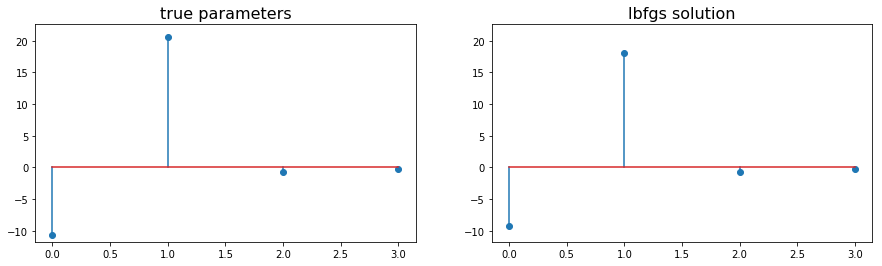

```
True parameters:  [-10.67517827  20.5306596   -0.79241992  -0.30796153]

lbfgs solution:  [-9.24269839 18.08110718 -0.68130437 -0.27719316]
```

```python
plt.figure(figsize=(15, 4))
plt.subplot(1, 2, 1)
plt.stem(true_params)
plt.title("true parameters", fontsize=16)
plt.ylim([np.min(true_params) * 1.1 , np.max(true_params) * 1.1])

plt.subplot(1, 2, 2)
plt.stem(lbfgs_params)
plt.title("lbfgs solution", fontsize=16)
plt.ylim([np.min(true_params) * 1.1 , np.max(true_params) * 1.1])
plt.show()

print ('True parameters: ', true_params)
print ('\nlbfgs solution: ', lbfgs_params)
```

```python
Y_proba = predict_proba(np.concatenate([eta_hat, beta_hat]))
y_pred = np.argmax(Y_proba, axis=1)

for j in range(k):
    Xj = X[y_pred == j]
    plt.plot(Xj[:, 0], Xj[:, 1], 'o', label='y = %d' % j, alpha=0.5)

plt.legend();
```

[output not shown]

### Computation of the gradients

We have so far been lazy by asking `fmin_l_bfgs_b` to approximate the gradient. You are going to fix this using either one of the next 2 options:

**QUESTION 7 (option 1):**

- Implement the function grad_negloglik that computes the gradient of negloglik.

**QUESTION 7 (option 2):**

- Implement the function grad_negloglik that computes the gradient of negloglik using the autograd package.

**HINT** : QUESTION 7 (option 1) you can use the fact that: $\log(\phi(t))' = 1 - \phi(t)$ and $\phi(t)' = \phi(t) (1 - \phi(t))$

You can check your implementation of the function `grad_negloglik` with the check_grad function. However **WARNING** your code is likely to be numerically quite unstable due to the numerous `log` and `exp` with tiny values that are probabilities. You may want to work with log of probabilities but **warning** this is not easy...

Denote $z_j := \alpha_j + \beta^T x_i = \sum_{l=1}^{j} \eta_l + \beta^T x_i$, then

$$\frac{\partial z_j}{\partial \eta_m} = \{ \begin{aligned} & 1, if \ j >= m \\ & 0, if \ j < m \end{aligned} $$

and $$\frac{\partial z_j}{\partial \beta} = x_i $$

Then $\mathcal{L}(\eta, \beta)$ could be re-written as:

$$ \mathcal{L}(\eta, \beta) = - \sum_{i=1}^{n} \{ \sum_{j=1}^{k} [y_{i,j}\log(\phi(z_j) - \phi(z_{j-1})] \} $$ Where we introduced that $\phi(z_0) = 0, \ \phi(z_k) = 1 $

Then:

Denote $M_j = \phi(z_j)' = \phi(z_j)(1-\phi(z_j))$, and $M_0 = \phi(z_0)' = 0' = 0, M_k = \phi(z_k)' = 1' = 0$, we have:

$$ \frac{\partial \mathcal{L}(\eta, \beta)}{\partial \eta_m} \\ = - \sum_{i=1}^{n} \{ \sum_{j=1}^{k}[\frac{y_{i,j}}{\phi(z_j) - \phi(z_{j-1})} (\frac{\partial \phi(z_j)}{\partial \eta_m} - \frac{\partial \phi(z_{j-1})}{\partial \eta_m}) ]\} \\ = - \sum_{i=1}^{n} \{ \sum_{j=1}^{k}[\frac{y_{i,j}}{\phi(z_j) - \phi(z_{j-1})} (\phi(z_j)'\frac{\partial z_j}{\partial \eta_m} - \phi(z_{j-1})'\frac{\partial z_{j-1}}{\partial \eta_m} )]\} \\ = - \sum_{i=1}^{n} \{ \sum_{j=1}^{k}[\frac{y_{i,j}}{\phi(z_j) - \phi(z_{j-1})} M_j \frac{\partial z_j}{\partial \eta_m}] -\sum_{j=1}^{k}[\frac{y_{i,j}}{\phi(z_j) - \phi(z_{j-1})} M_{j-1}\frac{\partial z_{j-1}}{\partial \eta_m}] \} \\ = - \sum_{i=1}^{n} \{ \sum_{j=m}^{k}[\frac{y_{i,j}}{\phi(z_j) - \phi(z_{j-1})} M_j] -\sum_{j={m+1}}^{k}[\frac{y_{i,j}}{\phi(z_j) - \phi(z_{j-1})} M_{j-1}] \} \\ = - \sum_{i=1}^{n} \{ \frac{y_{i,m}M_m}{\phi(z_m) - \phi(z_{m-1})} + \sum_{j={m+1}}^{k}[\frac{y_{i,j} (M_j - M_{j-1})}{\phi(z_j)- \phi(z_{j-1})} ]\} \\ = - \sum_{i=1}^{n} \{ \sum_{j={m}}^{k}[\frac{y_{i,j} (M_j - M_{j-1})}{\phi(z_j)- \phi(z_{j-1})}] + \frac{y_{i,m}M_{m-1}}{\phi(z_m) - \phi(z_{m-1})}\} $$

For numerical reason, (and the following implementation is of course not the most numerically stable version, but the result is acceptable and we take what we have) we will calculate above term as follows:

$$ \frac{\partial \mathcal{L}(\eta, \beta)}{\partial \eta_m} \\ = - \sum_{i=1}^{n} \{ \sum_{j=m}^{k-1}[\frac{y_{i,j}}{\phi(z_j) - \phi(z_{j-1})} M_j] -\sum_{j={m+1}}^{k}[\frac{y_{i,j}}{\phi(z_j) - \phi(z_{j-1})} M_{j-1}] + \frac{y_{i,k}}{\phi(z_j) - \phi(z_{k-1})} M_k\} $$

And we denote: $$ Term1 = \sum_{j=m}^{k-1}[\frac{y_{i,j}}{\phi(z_j) - \phi(z_{j-1})} M_j] \\ Term2 = \sum_{j={m+1}}^{k}[\frac{y_{i,j}}{\phi(z_j) - \phi(z_{j-1})} M_{j-1}] , \ and \\ Term3 = \frac{y_{i,k}}{\phi(z_j) - \phi(z_{k-1})} M_k $$

and $$\frac{\partial \mathcal{L}(\eta, \beta)}{\partial \beta} = - \sum_{i=1}^{n} \{ \sum_{j=1}^{k}[\frac{y_{i,j}}{\phi(z_j) - \phi(z_{j-1})} (\frac{\partial \phi(z_j)}{\partial \beta} - \frac{\partial \phi(z_{j-1})}{\partial \beta}) \} \\ = - \sum_{i=1}^{n} \{ \sum_{j=1}^{k}[\frac{y_{i,j}}{\phi(z_j) - \phi(z_{j-1})} (\phi(z_j)'\frac{\partial z_j}{\partial \beta} - \phi(z_{j-1})'\frac{\partial z_{j-1}}{\partial \beta}) ] \} \\ = - \sum_{i=1}^{n} \{ x_i \sum_{j=1}^{k}[\frac{y_{i,j} (M_j - M_{j-1})}{\phi(z_j) - \phi(z_{j-1})} ] \} $$

```python
# Option 1
from scipy.misc import logsumexp


def grad_negloglik(params, X=X, Y=Y):

    proba = predict_proba(params, X=X)    # = phi(z_j) -  phi(z_{j-1})
    assert Y.shape == proba.shape

    n_samples, n_features = X.shape
    n_classes = Y.shape[1]

    p = n_features
    k = n_classes

    phi = np.cumsum(proba, axis=1) # i.e. phi(z1), ..., phi(zk)
    Mj = phi * (1 - phi)           # phi(z_j)'

    zerocl = np.zeros((Mj.shape[0],1))
    Mjminus = np.column_stack((zerocl, Mj[:,0:k-1]))  # Mjminus

    Term1 = Y[:,0:k-1] * Mj[:,0:k-1] / (proba[:,0:k-1] + np.finfo('float').eps)      # m = 1, 2, ..., k-1
    Term2 = Y[:,1:k] * Mj[:,0:k-1] / (proba[:,1:k]  + np.finfo('float').eps)
    Term3 = Y[:,-1] * Mj[:,-1] /  (proba[:,-1] + np.finfo('float').eps)
    Term3_dim_expansion = np.repeat(Term3[:, np.newaxis],  Term1.shape[1], axis=1)
    ThreeTerms = Term1 - Term2 + Term3_dim_expansion

    addend_inbigBracket = np.flip(np.cumsum(np.flip(ThreeTerms, 1), axis=1), 1)
    delta_eta = -np.sum(addend_inbigBracket, axis=0)

    # calculating the derivatives for beta
    yijMjdp = Y * (Mj - Mjminus) / (proba + np.finfo('float').eps)
    pro_yijMjdp = np.sum(yijMjdp, axis=1)[:,np.newaxis]
    XyijM = X * pro_yijMjdp
    betas = -np.sum(XyijM, axis=0)

    delta = np.concatenate([delta_eta,betas])

    return delta
```

```python
# Option 2

import autograd.numpy as np
from autograd import grad

def negloglik_autograd(params, X=X, Y=Y):
    """Compute the negative log-likelihood

    Parameters
    ----------
    params : ndarray, shape (p + k - 1,)
        The parameters. The first k-1 values are the etas
        and the remaining p ones correspond to beta.
    X : ndarray, shape (n, p)
        Design matrix.
    Y : ndarray, shape (n, k)
        The target after one-hot encoding.

    Returns
    -------
    nlk : float
        The negative log-likelihood to be minimized.
    """
    # TODO

    proba = predict_proba(params, X=X)
    assert Y.shape == proba.shape

    return  -np.sum(np.sum(Y * np.log(proba  + np.finfo('float').eps),axis=1))


grad_negloglik_auto = grad(negloglik_autograd)
```

```python
from scipy.optimize import check_grad
rng = np.random.RandomState(7)
x0 = rng.randn(p + k - 1)
x0[1:k - 1] = np.abs(x0[1:k - 1])
# WARNING: check_grad is likely to return a quite high value
# due to numerical instability with exp and log with tiny
# probability values. Don't be surprised as long as your
# solvers below converge.
check_grad(negloglik, grad_negloglik, x0=x0)
```

```
36.60670530815789
```

The check_grad will return values between $0^+$ and up to thousands, depending on the different random seed. As above case, when we use randome seed of '7', check_grad returns 36 and if we compute the gradient with grad_negloglik_auto and grad_negloglik, the difference is not so big, so we accept what we have.

Now plug your gradient into L-BFGS and check the result:

```python
x0 = np.zeros(p + k - 1)
x0[:k - 1] = np.arange(k - 1)  # initiatlizing with etas all equal to zero is a bad idea!


bounds = [(None, None)] + [(0, np.inf) for j in range(k-2)] + [(None, None)] * p
x_hat, _, _ = fmin_l_bfgs_b(negloglik, fprime=grad_negloglik,
                            x0=x0, bounds=bounds)

x_hat_auto, _, _ = fmin_l_bfgs_b(negloglik, fprime=grad_negloglik_auto,
                            x0=x0, bounds=bounds)

Y_proba = predict_proba(x_hat)
y_pred = np.argmax(Y_proba, axis=1)

for j in range(k):
    Xj = X[y_pred == j]
    plt.plot(Xj[:, 0], Xj[:, 1], 'o', label='y = %d' % j, alpha=0.5)
plt.legend();
```

[output not shown]

### Q7 Analysis: Compare different gradient methods for calculating the parameters to the true parameters

```python
print ('True parameters:                                                       ', true_params)
print ('lbfgs solution with lbfgs calculating gradient (finit element method): ', lbfgs_params)
print ('lbfgs solution with autograd calculating gradient :                    ', x_hat_auto)
print ('lbfgs solution with our own gradient function:                         ', x_hat)
```

```
True parameters:                                                        [-10.67517827  20.5306596   -0.79241992  -0.30796153]
lbfgs solution with lbfgs calculating gradient (finit element method):  [-9.24269839 18.08110718 -0.68130437 -0.27719316]
lbfgs solution with autograd calculating gradient :                     [-9.24269644 18.08110331 -0.68130422 -0.2771931 ]
lbfgs solution with our own gradient function:                          [-9.24269644 18.08110331 -0.68130422 -0.2771931 ]
```

**QUESTION 9:**

- Wrap this into a function of X, y and lbda that implements the function proportional_odds_lbfgs_l2 that will be used to get a good value of x_min (minimum of the L2 regularized model).

To help you we give you the code of the objective to minimize in case you use $\ell_1$ or $\ell_2$ penalty.

```python
def pobj_l1(params, X=X, Y=Y, lbda=1.):
    n_features = X.shape[1]
    beta = params[-n_features:]
    n_thresh = Y.shape[1] - 1
    eta = params[:n_thresh]
    if np.any(eta[1:] < 0):
        return np.inf
    return negloglik(params, X=X, Y=Y) + lbda * np.sum(np.abs(beta))


def pobj_l2(params, X=X, Y=Y, lbda=1.):
    n_features = X.shape[1]
    beta = params[-n_features:]
    n_thresh = Y.shape[1] - 1
    eta = params[:n_thresh]
    if np.any(eta[1:] < 0):
        return np.inf
    return negloglik(params, X=X, Y=Y) + lbda / 0.5 * np.dot(beta, beta)
```

```python
def grad_l2(params, X=X, Y=Y, lbda=1.):
    # for l2 penalty, the gradient for eta is zero, the gradient for beta is lbda * beta

    n_features = X.shape[1]
    beta = params[-n_features:]
    l2_beta_grad = lbda * beta
    l2_grad = np.zeros((len(params)))
    l2_grad[-n_features:] = l2_beta_grad
    negloglik_term_grad = grad_negloglik(params, X, Y)

    return l2_grad + negloglik_term_grad


def proportional_odds_lbfgs_l2(X, y, lbda):
    Y = binarize(y)
    n_samples, n_features = X.shape
    n_classes = Y.shape[1]

    p = n_features
    k = n_classes
    # TODO
    x0 = np.zeros(p + k - 1)
    x0[:k - 1] = np.arange(k - 1)
    bounds = [(None, None)] + [(0, np.inf) for j in range(k-2)] + [(None, None)] * p
    x_min, _, _ = fmin_l_bfgs_b(pobj_l2, fprime=grad_l2,args=(X, Y, lbda),
                            x0=x0, bounds=bounds)

    # END TODO
    return x_min

x_min = proportional_odds_lbfgs_l2(X, y, lbda=1.)
```

```python
print ('True parameters:                                                       ', true_params)
print ('Solution from proportional_odds_lbfgs_l2 model:                        ', x_min)
```

```
True parameters:                                                        [-10.67517827  20.5306596   -0.79241992  -0.30796153]
Solution from proportional_odds_lbfgs_l2 model:                         [-9.20384256 18.0002628  -0.67827668 -0.27566383]
```

And indeed, we find that the beta absolute value is smaller than that of the true parameters.

Check that `x_min` is ok.

```python
Y_proba = predict_proba(x_min)
y_pred = np.argmax(Y_proba, axis=1)

for j in range(k):
    Xj = X[y_pred == j]
    plt.plot(Xj[:, 0], Xj[:, 1], 'o', label='y = %d' % j, alpha=0.5)

plt.legend();
```

[output not shown]

Now that we have a gradient of the negative loglikelihood term we can implement other solvers. Namely you are going to implement:

- Proximal Gradient Descent (PGD aka ISTA)
- Accelerated Proximal Gradient Descent (APGD aka FISTA)

Before this we are going to define the `monitor` class previously used in the second lab as well as plotting functions useful to monitor convergence.

```python
class monitor(object):
    def __init__(self, algo, obj, x_min, args=()):
        self.x_min = x_min
        self.algo = algo
        self.obj = obj
        self.args = args
        if self.x_min is not None:
            self.f_min = obj(x_min, *args)

    def run(self, *algo_args, **algo_kwargs):
        t0 = time.time()
        _, x_list = self.algo(*algo_args, **algo_kwargs)
        self.total_time = time.time() - t0
        self.x_list = x_list
        if self.x_min is not None:
            self.err = [linalg.norm(x - self.x_min) for x in x_list]
            self.obj = [self.obj(x, *self.args) - self.f_min for x in x_list]
        else:
            self.obj = [self.obj(x, *self.args) for x in x_list]


def plot_epochs(monitors, solvers):
    fig, (ax1, ax2) = plt.subplots(1, 2, figsize=(15, 5))
    for monit in monitors:
        ax1.semilogy(monit.obj, lw=2)
        ax1.set_title("Objective")
        ax1.set_xlabel("Epoch")
        ax1.set_ylabel("objective")

    ax1.legend(solvers)

    for monit in monitors:
        if monit.x_min is not None:
            ax2.semilogy(monit.err, lw=2)
            ax2.set_title("Distance to optimum")
            ax2.set_xlabel("Epoch")
            ax2.set_ylabel("$\|x_k - x^*\|_2$")

    ax2.legend(solvers)


def plot_time(monitors, solvers):
    for monit in monitors:
        objs = monit.obj
        plt.semilogy(np.linspace(0, monit.total_time, len(objs)), objs, lw=2)
        plt.title("Loss")
        plt.xlabel("Timing")
        plt.ylabel("$f(x_k) - f(x^*)$")

    plt.legend(solvers)
```

**QUESTION 8a:**

- Implement the proximal gradient descent (PGD) method

The parameter `step` is the size of the gradient step.

```python
def pgd(x_init, grad, prox, n_iter=100, step=1., store_every=1,
        grad_args=(), prox_args=()):
    """Proximal gradient descent algorithm."""
    x = x_init.copy()
    x_list = []
    for i in range(n_iter):

        ### TODO
        # grad should be the gradient of negloglik, there is no penalty term here
        x = prox(x - step * grad(x, *grad_args), *prox_args)
        ### END TODO
        if i % store_every == 0:
            x_list.append(x.copy())
    return x, x_list
```

**QUESTION 8b:**

- Using the monitor class and the plot_epochs function, display the convergence.

NOTE: You will have to provide a `step` value, which should be theoretially less than `1 / lipschitz_constant`. You will propose a value for it but you are not expected to provide a mathematical proof, unless you think it's a moral duty to give one...

#### The step size

We choose the lipschitz_constant as $\frac{\Vert X \Vert^2}{4}$ since essentially this problem is a logistic regression, and the lipschitz constant of logistic regression is $\frac{\Vert X \Vert^2}{4}$. Please notice, this is not a strictly mathematically proof, but a rough guess based on our assumption.

To help you we give you the proximal operator functions for $\ell_1$ and $\ell_2$ regularized models.

```python
def prox_l1(params, step, lbda, n_classes):
    return prox_f1(params, reg=step * lbda, n_classes=n_classes)

def prox_l2(params, step, lbda, n_classes):
    return prox_f2(params, reg=step * lbda, n_classes=n_classes)
```

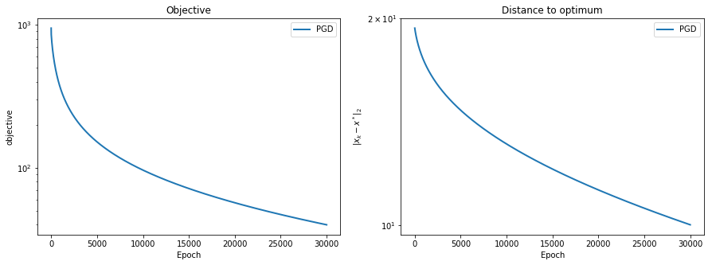

```python
x_init = np.zeros(p + k - 1)
x_init[:k - 1] = np.arange(k - 1)
n_iter = 30000
lbda = .1

lips_const = np.linalg.norm(X) ** 2 / 4
step = 1 /  lips_const  # the step function analysis should be added

monitor_pgd_l2 =  monitor(pgd, pobj_l2, x_min, (X, Y, lbda))
monitor_pgd_l2.run(x_init, grad_negloglik, prox_l2, n_iter, step,
                   grad_args=(X, Y), prox_args=(step, lbda, k))

monitors = [monitor_pgd_l2]
solvers = ["PGD"]
plot_epochs(monitors, solvers)
```

Now for the $\ell_1$ regularization:

[figure not shown]

```python
lbda = 1.

# Run PGD for L1
monitor_pgd_l1 = monitor(pgd, pobj_l1, x_min, args=(X, Y, lbda))
monitor_pgd_l1.run(x_init, grad_negloglik, prox_l1, n_iter, step,
                   grad_args=(X, Y), prox_args=(step, lbda, k))

monitors = [monitor_pgd_l1]
solvers = ["PGD"]
plot_epochs(monitors, solvers)
```

**QUESTION 9:**

- Implement the accelerated proximal gradient descent (APGD) and add this solver to the monitoring plots.

```python
def apgd(x_init, grad, prox, n_iter=100, step=1., store_every=1,
        grad_args=(), prox_args=()):
    """Accelerated proximal gradient descent algorithm."""
    x = x_init.copy()
    y = x_init.copy()
    t = 1.
    x_list = []

    t_new = 1
    b = 1
    for i in range(n_iter):
        ### TODO
        x_new = prox(y - step * grad(y, *grad_args), *prox_args)
        b_new =  (1. + (1. + 4. * b ** 2.) ** 0.5) / 2.
        y = x_new + (b - 1.) / b_new * (x_new - x)
        x = x_new
        b = b_new

        ### END TODO
        if i % store_every == 0:
            x_list.append(x.copy())
    return x, x_list
```

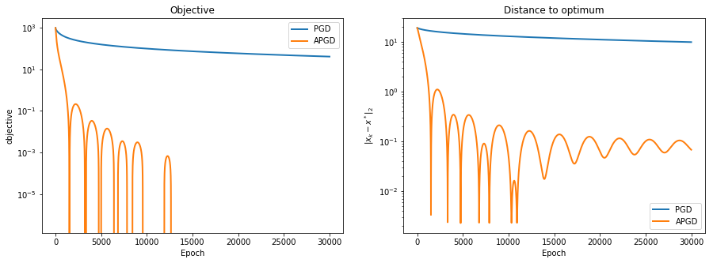

```python
lbda = 0.1

# TODO
monitor_apgd_l2 =  monitor(apgd, pobj_l2, x_min, args=(X, Y, lbda))
monitor_apgd_l2.run(x_init, grad_negloglik, prox_l2, n_iter, step,
                   grad_args=(X, Y), prox_args=(step, lbda, k))


# END TODO

monitors = [monitor_pgd_l2, monitor_apgd_l2]
solvers = ["PGD", "APGD"]
plot_epochs(monitors, solvers)
```

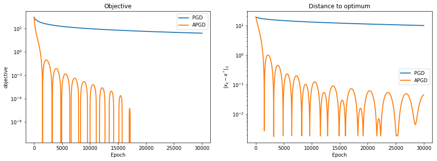

```python
lbda = 1.


# TODO
monitor_apgd_l1 =  monitor(apgd, pobj_l1, x_min, args=(X, Y, lbda))
monitor_apgd_l1.run(x_init, grad_negloglik, prox_l1, n_iter, step,
                   grad_args=(X, Y), prox_args=(step, lbda, k))
# END TODO

monitors = [monitor_pgd_l1, monitor_apgd_l1]
solvers = ["PGD", "APGD"]
plot_epochs(monitors, solvers)
```

# Part 2: Application

You will now apply your solver to the `wine quality` dataset. Given 11 features that describe certain wines (our samples), the objective it to predict the quality of the wine, encoded by integers between 3 and 8. Rather than using a multiclass classification model we're going to use a proportional odds model.

Let's first inspect the dataset:

```python
import pandas as pd
df = pd.read_csv('winequality-red.csv', delimiter=';')
df.tail()
```

|  | fixed acidity | volatile acidity | citric acid | residual sugar | chlorides | free sulfur dioxide | total sulfur dioxide | density | pH | sulphates | alcohol | quality |
| --- | --- | --- | --- | --- | --- | --- | --- | --- | --- | --- | --- | --- |
| 1594 | 6.2 | 0.600 | 0.08 | 2.0 | 0.090 | 32.0 | 44.0 | 0.99490 | 3.45 | 0.58 | 10.5 | 5 |
| 1595 | 5.9 | 0.550 | 0.10 | 2.2 | 0.062 | 39.0 | 51.0 | 0.99512 | 3.52 | 0.76 | 11.2 | 6 |
| 1596 | 6.3 | 0.510 | 0.13 | 2.3 | 0.076 | 29.0 | 40.0 | 0.99574 | 3.42 | 0.75 | 11.0 | 6 |
| 1597 | 5.9 | 0.645 | 0.12 | 2.0 | 0.075 | 32.0 | 44.0 | 0.99547 | 3.57 | 0.71 | 10.2 | 5 |
| 1598 | 6.0 | 0.310 | 0.47 | 3.6 | 0.067 | 18.0 | 42.0 | 0.99549 | 3.39 | 0.66 | 11.0 | 6 |

```python
df['quality'].unique()
```

```
array([5, 6, 7, 4, 8, 3])
```

Now let's extract `X` and `y`

```python
data = df.values
X = data[:, :-1]
y = data[:, -1] - 3
X.shape, y.shape, np.unique(y)
```

```
((1599, 11), (1599,), array([0., 1., 2., 3., 4., 5.]))
```

Let's do a basic scaling of the features:

```python
from sklearn.preprocessing import scale
X = scale(X)
```

Now test the functions above with this dataset:

```python
x_init = np.zeros(X.shape[1] + np.unique(y).size - 1)
Y = binarize(y)
negloglik(x_init, X=X, Y=Y)
grad_negloglik(x_init, X=X, Y=Y)
```

```
array([ 4.00000000e+00, -5.96726951e+16, -7.66737837e+17, -7.18324141e+17,
       -2.24054081e+17,  1.16138509e+00, -1.52163446e+01,  8.11900904e+00,
       -9.23896449e-02, -7.36157019e+00,  9.56606711e-02, -2.84967585e-01,
       -9.22049809e+00, -5.37425526e+00,  8.42355391e+00,  1.63170073e+01])
```

In order to facilitate our experiment we're going to write a full scikit-learn estimator.

**QUESTION 10:**

- Implement the `fit` method from the estimator in the next cell

```python
from sklearn.base import BaseEstimator, ClassifierMixin


class ProportionalOdds(BaseEstimator, ClassifierMixin):
    """scikit-learn estimator for the proportional odds model

    Parameters
    ----------
    lbda : float
        The regularization parameter
    penalty : 'l1' | 'l2'
        The type of regularization to use.
    max_iter : int
        The number of iterations / epochs to do on the data.
    solver : 'pgd' | 'apgd' | 'lbfgs'
        The type of regularization to use.
        'lbfgs' is only supported with penalty='l2'.

    Attributes
    ----------
    alpha_ : ndarray, (n_classes - 1,)
        The alphas.
    beta_ : ndarray, (n_features,)
        The regression coefficients.
    """
    def __init__(self, lbda=1., penalty='l2', max_iter=2000,
                 solver='lbfgs'):
        self.lbda = lbda
        self.penalty = penalty
        self.max_iter = max_iter
        self.solver = solver
        assert self.penalty in ['l1', 'l2']
        assert self.solver in ['pgd', 'apgd', 'lbfgs']

    def fit(self, X, y):
        """Fit method

        Parameters
        ----------
        X : ndarray, shape (n_samples, n_features)
            The features.
        y : ndarray, shape (n_samples,)
            The target. Must be integers between 0 and n_classes - 1.
        """
        n_classes = int(np.max(y)) + 1
        assert np.all(np.unique(y) == np.arange(n_classes))
        Y = binarize(y)
        n_samples, n_features = X.shape
        # TODO

        # find the min value with lbfgs
        p = n_features
        k = Y.shape[1]

        lips_const = np.linalg.norm(X) ** 2 / 4
        step = 1 /  lips_const    # step value to be analyzed


        x_init = np.zeros(p + k - 1)
        x_init[:k - 1] = np.arange(k - 1)


        if self.penalty == 'l1':
            objf = pobj_l1
            proxf = prox_l1
        elif  self.penalty == 'l2':
            objf = pobj_l2
            proxf = prox_l2

        if  self.solver == "lbfgs":
            if self.penalty == 'l2':
                bounds = [(None, None)] + [(0, np.inf) for j in range(k-2)] + [(None, None)] * p
                result = fmin_l_bfgs_b(negloglik, x_init, fprime=None, args=(X, Y), approx_grad=1,bounds=bounds)
                x = result[0]

        elif self.solver == "pgd" or  self.solver == "apgd":
            if self.solver == "pgd":
                solver = pgd
            else:
                solver = apgd

            monitor_solver =  monitor(solver, objf, x_min=None, args=(X, Y, lbda))
            monitor_solver.run(x_init, grad_negloglik, proxf, self.max_iter, step, 1, (X, Y), (step, lbda, k))
            x = monitor_solver.x_list[-1]


        beta = x[-n_features:]
        n_thresh = k - 1
        eta = x[:n_thresh]

        # END TODO
        self.params_ = x
        self.alpha_ = eta.cumsum()
        self.beta_ = beta
        return self

    def predict(self, X):
        """Predict method

        Parameters
        ----------
        X : ndarray, shape (n_samples, n_features)
            The features.

        Returns
        -------
        y_pred : ndarray, shape (n_samples,)
            The predicted target.
        """
        return np.argmax(self.predict_proba(X), axis=1)

    def predict_proba(self, X):
        """Predict proba method

        Parameters
        ----------
        X : ndarray, shape (n_samples, n_features)
            The features.

        Returns
        -------
        y_proba : ndarray, shape (n_samples, n_classes)
            The predicted probabilities.
        """
        return predict_proba(self.params_, X)


for solver in ['pgd', 'apgd', 'lbfgs']:
    clf = ProportionalOdds(lbda=1., penalty='l2', max_iter=1000, solver=solver)
    clf.fit(X, y)
    print('Solver with L2: %s   -   Score : %s' % (solver, clf.score(X, y)))

for solver in ['pgd', 'apgd']:
    clf = ProportionalOdds(lbda=1., penalty='l1', max_iter=1000, solver=solver)
    clf.fit(X, y)
    print('Solver with L1: %s   -   Score : %s' % (solver, clf.score(X, y)))
```

```
Solver with L2: pgd   -   Score : 0.5953721075672295
Solver with L2: apgd   -   Score : 0.5953721075672295
Solver with L2: lbfgs   -   Score : 0.5947467166979362
Solver with L1: pgd   -   Score : 0.5947467166979362
Solver with L1: apgd   -   Score : 0.5941213258286429
```

**QUESTION 11:**

- Compare the cross-validation performance of your model with a multinomial logistic regression model that ignores the order between the classes. You will comment your results.

```python
from sklearn.linear_model import LogisticRegression
from sklearn.model_selection import cross_val_score

# TODO
k = 4 # number of cross validation folder

clf_logR_mutilnomial = LogisticRegression(random_state=0, solver='lbfgs',multi_class='multinomial').fit(X,y)
logR_cvs = cross_val_score(clf_logR_mutilnomial, X, y, cv=k)

clf_pgd_l2 = ProportionalOdds(lbda=1., penalty='l2', max_iter=1000, solver='pgd').fit(X,y)
pgd_l2_cvs = cross_val_score(clf_pgd_l2, X, y, cv=k,scoring='accuracy')

clf_apgd_l2 = ProportionalOdds(lbda=1., penalty='l2', max_iter=1000, solver='apgd').fit(X,y)
apgd_l2_cvs = cross_val_score(clf_apgd_l2, X, y, cv=k, scoring='accuracy')

clf_lbfgs_l2 = ProportionalOdds(lbda=1., penalty='l2', max_iter=1000, solver='lbfgs').fit(X,y)
lbfgs_l2_cvs = cross_val_score(clf_lbfgs_l2, X, y, cv=k, scoring='accuracy')

clf_pgd_l1 = ProportionalOdds(lbda=1., penalty='l1', max_iter=1000, solver='pgd').fit(X,y)
pgd_l1_cvs = cross_val_score(clf_pgd_l1, X, y, cv=k, scoring='accuracy')


clf_apgd_l1 = ProportionalOdds(lbda=1., penalty='l1', max_iter=1000, solver='apgd').fit(X,y)
apgd_l1_cvs = cross_val_score(clf_apgd_l1, X, y, cv=k, scoring='accuracy')
```

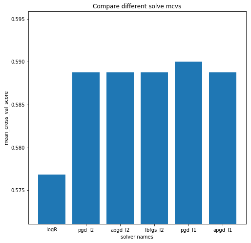

```python
solver_count = np.arange(6)
m_cvs = [logR_cvs.mean(), pgd_l2_cvs.mean(), apgd_l2_cvs.mean(),  lbfgs_l2_cvs.mean(), pgd_l1_cvs.mean(),   apgd_l1_cvs.mean()]

plt.figure(figsize=(8, 8))
plt.bar(solver_count, m_cvs)
plt.xticks(solver_count, ('logR', 'pgd_l2', 'apgd_l2', 'lbfgs_l2', 'pgd_l1', 'apgd_l1'))
plt.ylim([np.min(m_cvs)*(1 - 0.01), np.max(m_cvs) * (1 + 0.01)])
plt.title('Compare different solve mcvs')
plt.xlabel('solver names')
plt.ylabel('mean_cross_val_score')
plt.show()
```

### Comments

As shown from above graph, multinomial logistic regression model that ignores the order between the classes underperform all other models which do consider the order between classes. This means the order does matter. Intutively speaking, the distance between a very good wine to a good wine is closer than a very good wine to a bad wine.

```python
print('Display the cross valiation score for different method: \n')
print ('solver_name:         cross_val_score_for_' + str(k) + '_folders             mean_cross_val_score\n')
print ('logR_cvs:        ', logR_cvs, logR_cvs.mean())
print ('pgd_l2_cvs:      ', pgd_l2_cvs, pgd_l2_cvs.mean())
print ('apgd_l2_cvs:     ', apgd_l2_cvs, apgd_l2_cvs.mean())
print ('lbfgs_l2_cvs:    ', lbfgs_l2_cvs, lbfgs_l2_cvs.mean())
print ('pgd_l1_cvs:      ', pgd_l1_cvs, pgd_l1_cvs.mean())
print ('apgd_l1_cvs:     ', apgd_l1_cvs, apgd_l1_cvs.mean())
```

```
Display the cross valiation score for different method:

solver_name:         cross_val_score_for_4_folders             mean_cross_val_score

logR_cvs:         [0.52109181 0.55610973 0.6080402  0.62216625] 0.5768519962391471
pgd_l2_cvs:       [0.53101737 0.56109726 0.63819095 0.62468514] 0.5887476799744538
apgd_l2_cvs:      [0.53101737 0.56109726 0.63819095 0.62468514] 0.5887476799744538
lbfgs_l2_cvs:     [0.53101737 0.56109726 0.63819095 0.62468514] 0.5887476799744538
pgd_l1_cvs:       [0.53101737 0.56608479 0.64070352 0.62216625] 0.5899929805490745
apgd_l1_cvs:      [0.53101737 0.56359102 0.63819095 0.62216625] 0.588741398449048
```

# Questions:

- Q1: Why we have the difference between pgd_l1 and other models
- Q2: When i run with different k values, I have very different result. See as follows, for k = 3 or 5, this is one fold that the cross_val_score is very low. Why this happens?

```python
k = 3
clf_apgd_l1 = ProportionalOdds(lbda=1., penalty='l1', max_iter=1000, solver='apgd').fit(X,y)
apgd_l1_cvs = cross_val_score(clf_apgd_l1, X, y, cv=k, scoring='accuracy')
apgd_l1_cvs
```

```
array([0.54392523, 0.03377111, 0.61581921])
```

```python
k = 5
clf_apgd_l1 = ProportionalOdds(lbda=1., penalty='l1', max_iter=1000, solver='apgd').fit(X,y)
apgd_l1_cvs = cross_val_score(clf_apgd_l1, X, y, cv=k, scoring='accuracy')
apgd_l1_cvs
```

```
array([0.52173913, 0.57320872, 0.03426791, 0.59433962, 0.62460568])
```